# practical_exercise_7 , Methods 3, 2021, autumn semester

Rikke Uldbæk

10/11

```r
#packages
pacman::p_load(reticulate, Rcpp)
```

# Exercises and objectives

1. Estimate bias and variance based on a true underlying function
2. Fitting training data and applying it to test sets with and without regularization

For each question and sub-question, please indicate one of the three following answers:  
i. I understood what was required of me  
ii. I understood what was required of me, but I did not know how to fulfil the requirement  
iii. I did not understand what was required of me

# EXERCISE 1 - Estimate bias and variance based on a true underlying function

We can express regression as $y = f(x) + \epsilon$ with $E[\epsilon] = 0$ (expected error of 0) and $var(\epsilon) = \sigma^2$ ($E$ means expected value)

For a given point: $x_0$, we can decompose the expected prediction error , $E[(y_0 - \hat{f}(x_0))^2]$ into three parts - **bias**, **variance** and **irreducible error** (the first two together are the **reducible error**):

The expected prediction error is, which we also call the **Mean Squared Error**:  
$E[(y_0 - \hat{f}(x_0))^2] = bias(\hat{f}(x_0))^2 + var(\hat{f}(x_0)) + \sigma^2$ *Så mean squared error består af bias, variance or irriducible error, se overstående formel* ^

where **bias** is;

$bias(\hat{f}(x_0)) = E[\hat{f}(x_0)] - f(x_0)$

1. Create a function, $f(x)$ that squares its input. This is our **true** function
   1. generate data, $y$, based on an input range of [0, 6] with a spacing of 0.1. Call this $x$
   2. add normally distributed noise to $y$ with $\sigma=5$ (set a seed to 7 `np.random.seed(7)`) to $y$ and call it $y_{noisy}$
   3. plot the true function and the generated points

```python
import numpy as np
np.random.seed(7)
import pandas as pd

from matplotlib import pyplot as plt

#create a function that squares its input
def true_function(x):
    return x**2

# i. generate data, ytrue, based on an input range of [0, 6] with a spacing of 0.1
x = np.arange(0, 6.1, 0.1) # lav x's


y = true_function(x) #generer y ud fra true_function using x


# ii. add normally distributed noise to ytrue with σ = 5 (set a seed to 7 np.random.seed(7)) and call it y_noise
noise= np.random.normal(loc = 0, scale= 5, size = len(y))

y_noisy = y+noise

# iii. plot the true function and the generated points
plt.figure()
plt.plot(x, y, "g") #function generated y's
plt.plot(x, y_noisy, "ro")
plt.title("plot4lyfe")
plt.legend(["yo dawg", "hehe"])
plt.show()
```

[output not shown]

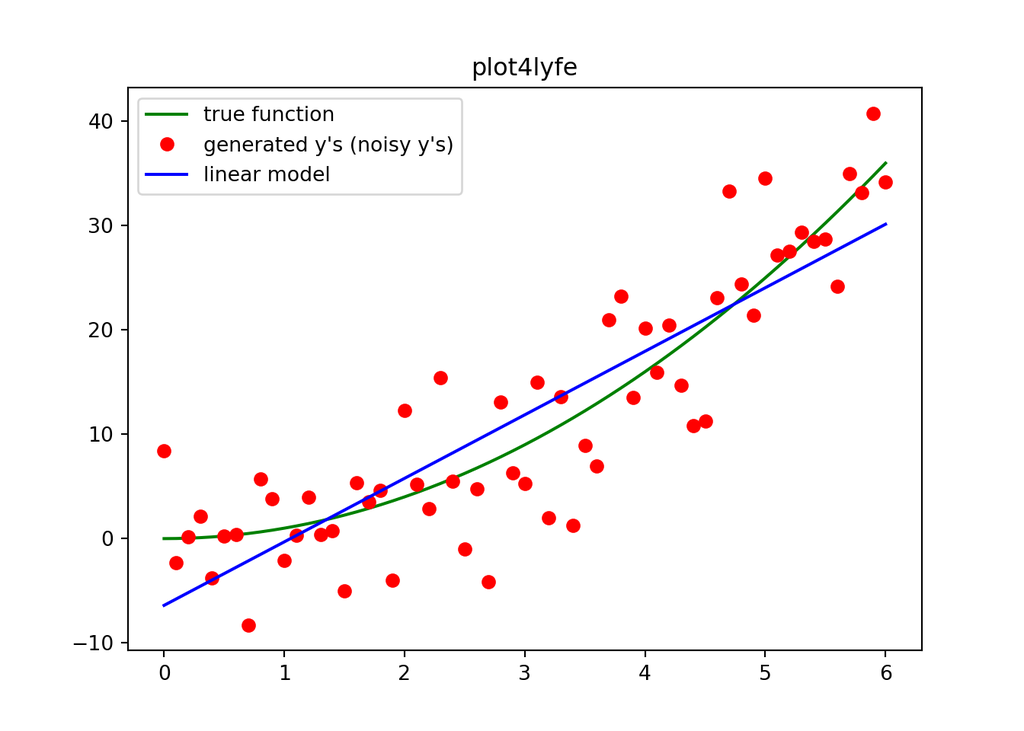

```python
#Fit a linear regression using `LinearRegression` from `sklearn.linear_model` based on $y_{noisy}$ and $x$ (see code chunk below associated with Exercise 1.2)
from sklearn.linear_model import LinearRegression #import things
x=x.reshape(61,1) #vi skal lige reshape x fordi den er lidt mærkelig, husk assign til x, ellers er det fucked

lin_reg_model = LinearRegression().fit(x, y_noisy) #make da model

r.sq = lin_reg_model.score(x, y_noisy) #making r^2


#i. plot the fitted line (see the `.intercept_` and `.coef_` attributes of the `regressor` object) on top of the plot (from 1.1.iii)

intercept = lin_reg_model.intercept_ #PRINTING INTERCEPT
slope = lin_reg_model.coef_ # printing SLOPE

predict_y = lin_reg_model.predict(x) #lav predicted values ud fra model (i.e plot intercept og slope, eller i hvertfald de værdier som disse betaer genererer)

plt.figure()
plt.plot(x, y, "g") #function generated y's
plt.plot(x, y_noisy, "ro")
plt.plot(x, predict_y, "b") #linear regression generated y's
plt.title("plot4lyfe")
plt.legend(["true function", "generated y's (noisy y's)", "linear model"])
plt.show()


#ii. now run the code chunk below associated with Exercise 1.2.ii - what does X_quadratic amount to?

# Exercise 1.2.ii
```

```python
from sklearn.preprocessing import PolynomialFeatures
quadratic = PolynomialFeatures(degree=2)
X_quadratic = quadratic.fit_transform(x.reshape(-1, 1)) # X matrix
regressor = LinearRegression() #renaming stuff for simplicity, men det er underordnet
quadratic_model = regressor.fit(X_quadratic, y_noisy)

y_quadratic_hat = quadratic_model.predict(X_quadratic)

X_quadratic

#plot of quadratic model
```

```
## array([[1.000e+00, 0.000e+00, 0.000e+00],
##        [1.000e+00, 1.000e-01, 1.000e-02],
##        [1.000e+00, 2.000e-01, 4.000e-02],
##        [1.000e+00, 3.000e-01, 9.000e-02],
##        [1.000e+00, 4.000e-01, 1.600e-01],
##        [1.000e+00, 5.000e-01, 2.500e-01],
##        [1.000e+00, 6.000e-01, 3.600e-01],
##        [1.000e+00, 7.000e-01, 4.900e-01],
##        [1.000e+00, 8.000e-01, 6.400e-01],
##        [1.000e+00, 9.000e-01, 8.100e-01],
##        [1.000e+00, 1.000e+00, 1.000e+00],
##        [1.000e+00, 1.100e+00, 1.210e+00],
##        [1.000e+00, 1.200e+00, 1.440e+00],
##        [1.000e+00, 1.300e+00, 1.690e+00],
##        [1.000e+00, 1.400e+00, 1.960e+00],
##        [1.000e+00, 1.500e+00, 2.250e+00],
##        [1.000e+00, 1.600e+00, 2.560e+00],
##        [1.000e+00, 1.700e+00, 2.890e+00],
##        [1.000e+00, 1.800e+00, 3.240e+00],
##        [1.000e+00, 1.900e+00, 3.610e+00],
##        [1.000e+00, 2.000e+00, 4.000e+00],
##        [1.000e+00, 2.100e+00, 4.410e+00],
##        [1.000e+00, 2.200e+00, 4.840e+00],
##        [1.000e+00, 2.300e+00, 5.290e+00],
##        [1.000e+00, 2.400e+00, 5.760e+00],
##        [1.000e+00, 2.500e+00, 6.250e+00],
##        [1.000e+00, 2.600e+00, 6.760e+00],
##        [1.000e+00, 2.700e+00, 7.290e+00],
##        [1.000e+00, 2.800e+00, 7.840e+00],
##        [1.000e+00, 2.900e+00, 8.410e+00],
##        [1.000e+00, 3.000e+00, 9.000e+00],
##        [1.000e+00, 3.100e+00, 9.610e+00],
##        [1.000e+00, 3.200e+00, 1.024e+01],
##        [1.000e+00, 3.300e+00, 1.089e+01],
##        [1.000e+00, 3.400e+00, 1.156e+01],
##        [1.000e+00, 3.500e+00, 1.225e+01],
##        [1.000e+00, 3.600e+00, 1.296e+01],
##        [1.000e+00, 3.700e+00, 1.369e+01],
##        [1.000e+00, 3.800e+00, 1.444e+01],
##        [1.000e+00, 3.900e+00, 1.521e+01],
##        [1.000e+00, 4.000e+00, 1.600e+01],
##        [1.000e+00, 4.100e+00, 1.681e+01],
##        [1.000e+00, 4.200e+00, 1.764e+01],
##        [1.000e+00, 4.300e+00, 1.849e+01],
##        [1.000e+00, 4.400e+00, 1.936e+01],
##        [1.000e+00, 4.500e+00, 2.025e+01],
##        [1.000e+00, 4.600e+00, 2.116e+01],
##        [1.000e+00, 4.700e+00, 2.209e+01],
##        [1.000e+00, 4.800e+00, 2.304e+01],
##        [1.000e+00, 4.900e+00, 2.401e+01],
##        [1.000e+00, 5.000e+00, 2.500e+01],
##        [1.000e+00, 5.100e+00, 2.601e+01],
##        [1.000e+00, 5.200e+00, 2.704e+01],
##        [1.000e+00, 5.300e+00, 2.809e+01],
##        [1.000e+00, 5.400e+00, 2.916e+01],
##        [1.000e+00, 5.500e+00, 3.025e+01],
##        [1.000e+00, 5.600e+00, 3.136e+01],
##        [1.000e+00, 5.700e+00, 3.249e+01],
##        [1.000e+00, 5.800e+00, 3.364e+01],
##        [1.000e+00, 5.900e+00, 3.481e+01],
##        [1.000e+00, 6.000e+00, 3.600e+01]])
```

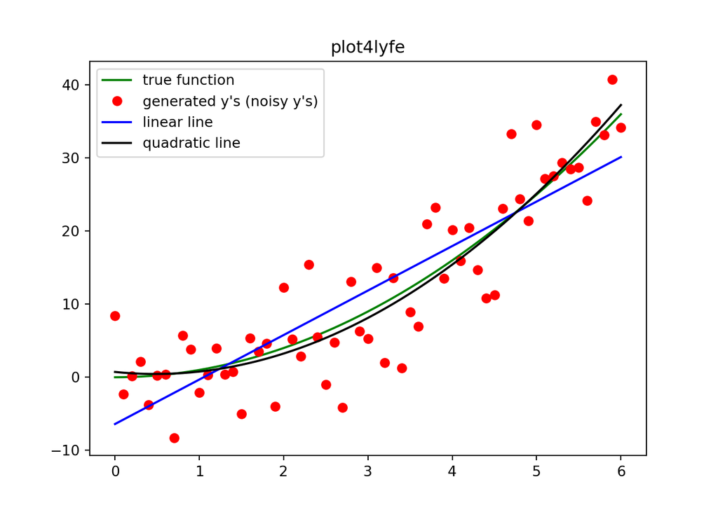

```python
plt.figure()
plt.plot(x, y, "g") #function generated y's
plt.plot(x, y_noisy, "ro")
plt.plot(x, predict_y, "b") #linear regression generated y's
plt.plot(x, y_quadratic_hat, "black") #quadratic model generated y's
plt.title("plot4lyfe")
plt.legend(["true function", "generated y's (noisy y's)", "linear line", "quadratic line"])
plt.show()


#iii. do a quadratic and a fifth order fit as well and plot them (on top of the plot from 1.2.i)
```

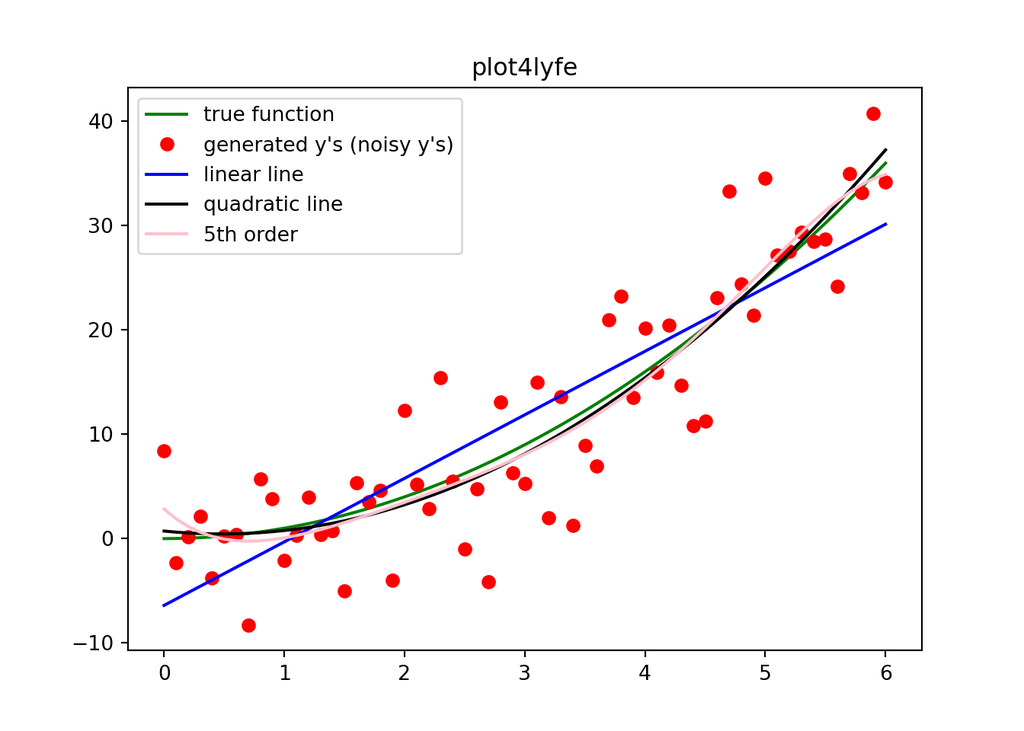

```python
from sklearn.preprocessing import PolynomialFeatures
fifth_order = PolynomialFeatures(degree=5)
X_fifth_order = fifth_order.fit_transform(x.reshape(-1, 1)) # X matrix
regressor = LinearRegression() #renaming stuff for simplicity, men det er underordnet
fifth_order_model = regressor.fit(X_fifth_order, y_noisy)

y_fifth_order_hat = fifth_order_model.predict(X_fifth_order)

#plot of fifth order model
plt.figure()
plt.plot(x, y, "g") #function generated y's
plt.plot(x, y_noisy, "ro")
plt.plot(x, predict_y, "b") #linear regression generated y's
plt.plot(x, y_quadratic_hat, "black") #quadratic model generated y's
plt.plot(x, y_fifth_order_hat, "pink") #fifth order model generated y's
plt.title("plot4lyfe")
plt.legend(["true function", "generated y's (noisy y's)", "linear line", "quadratic line", "5th order"])
plt.show()
```

3. Simulate 100 samples, each with sample size `len(x)` with $\sigma=5$ normally distributed noise added on top of the true function

```python
# simulate 100 samples each sample size `len(x)` with $\sigma=5$ normally distributed noise added on top of the true function
y_sample_list = [y + np.random.normal(loc = 0, scale= 5, size = len(x)) for i in range(100)]
```

1. do linear, quadratic and fifth-order fits for each of the 100 samples

```python
#predict fits for the 3 models
from sklearn.linear_model import LinearRegression #import things

regressor = LinearRegression() # make the regressor (lm)
linear_list= [] #empty list

for i in range(100):
  linear_fits = regressor.fit(x, y_sample_list) #make da model 100 times
  predicted_linear_ys = linear_fits.predict(x)
  linear_list.append(i)
```

2. create a **new** figure, `plt.figure`, and plot the linear and the quadratic fits (colour them appropriately); highlight the true value for $x_0=3$. From the graphics alone, judge which fit has the highest bias and which has the highest variance for $x_0$
   3. create a **new** figure, `plt.figure`, and plot the quadratic and the fifth-order fits (colour them appropriately); highlight the true value for $x_0=3$. From the graphics alone, judge which fit has the highest bias and which has the highest variance for $x_0$
   4. estimate the **bias** and **variance** at $x_0$ for the linear, the quadratic and the fifth-order fits (the expected value $E[\hat{f}(x_0)] - f(x_0)$ is found by taking the mean of all the simulated, $\hat{f}(x_0)$, differences)
   5. show how the **squared bias** and the **variance** is related to the complexity of the fitted models
   6. simulate **epsilon**: `epsilon = np.random.normal(scale=5, size=100)`. Based on your simulated values of **bias, variance and epsilon**, what is the **Mean Squared Error** for each of the three fits? Which fit is better according to this measure?